# Omar-ElAzazy: Traffic Data Analysis

Omar ElAzazy, 25-1136

Summary:

The most crowded day is Monday, most crowded hour is 6 PM and the most crowded area is “Lotfy ElSayed”.

The least croawded day is Friday, least crowded hour is 5 AM and the least crowded area is “Gharda2ah/Sokhna Rd.”.

Reading the data.

```r
data <- read.csv(file="../traffic-data.csv", sep=",")
data %>% summary()
```

```
##                         crawl_date         ad.aid        ad.bgcl
##  Sun Feb 14 22:30:08 UTC 2016:   120   Min.   :2538   #003768:429982
##  Sun Feb 14 22:30:10 UTC 2016:   120   1st Qu.:2538
##  Sun Feb 14 22:30:11 UTC 2016:   120   Median :2538
##  Sun Feb 14 22:30:14 UTC 2016:   120   Mean   :2538
##  Sun Feb 14 22:30:15 UTC 2016:   120   3rd Qu.:2538
##  Sun Feb 14 23:00:09 UTC 2016:   120   Max.   :2538
##  (Other)                     :429262
##     ad.bgcls         ad.fncl          ad.fncls          ad.lid
##  #0069aa:429982   #FFFFFF:429982   #FFFFFF:429982   Min.   :1001
##                                                     1st Qu.:1001
##                                                     Median :1001
##                                                     Mean   :1001
##                                                     3rd Qu.:1001
##                                                     Max.   :1001
##
##                                                      ad.logo
##  http://www.bey2ollak.com/downloads/logos/Pepsi_SA7EL.png:429982
##
##
##
##
##
##
##                                                        ad.logo2x
##  http://www.bey2ollak.com/downloads/logos/Pepsi_SA7EL@2x.png:429982
##
##
##
##
##
##
##                                                            ad.logoAndroidS
##  http://www.bey2ollak.com/downloads/logos/Pepsi_SA7EL_ANDROID_S.png:429982
##
##
##
##
##
##
```

[output cut: 57 more lines]

```
##  Min.   : 0.0   Min.   : 1.00   lazeez       : 76106   Min.   :9271509
##  1st Qu.:14.0   1st Qu.: 2.00   mashy        : 21710   1st Qu.:9338581
##  Median :29.0   Median : 3.00   7alawa       : 16996   Median :9376096
##  Mean   :29.2   Mean   : 4.71   za7ma        : 14183   Mean   :9376278
##  3rd Qu.:44.0   3rd Qu.:10.00   Eih el nezam?: 14127   3rd Qu.:9413977
##  Max.   :59.0   Max.   :10.00   mafeesh amal :  7904   Max.   :9452302
##                 NA's   :13965   (Other)      :278956
##   rd.rp.rpImg       rd.rp.img        rd.rp.type
##  Min.   : 21970   Min.   :    50   Min.   :0
##  1st Qu.:458600   1st Qu.: 62923   1st Qu.:0
##  Median :461455   Median : 62923   Median :0
##  Mean   :461014   Mean   :146707   Mean   :0
##  3rd Qu.:464205   3rd Qu.:233366   3rd Qu.:0
##  Max.   :467309   Max.   :467247   Max.   :0
##  NA's   :411585   NA's   :152557
```

The data contains the crawl data, advertisement related columns, the road name, the hour and minute the road was last updated, some other road related columns, the username of the reporter, the full name of the reporter, the hour and minute since the report was made, the comment in the report, and some report related columns.

Let’s check the unique value in each column.

```r
data %>% sapply(function(x) x %>% unique() %>% length)
```

```
##      crawl_date          ad.aid         ad.bgcl        ad.bgcls
##           28331               1               1               1
##         ad.fncl        ad.fncls          ad.lid         ad.logo
##               1               1               1               1
##       ad.logo2x ad.logoAndroidS ad.logoAndroidH           ad.cm
##               1               1               1               1
##          ad.url            ad.g           rd.nm           rd.ri
##               1               1             301             305
##         rd.stid           rd.hr           rd.mn          rd.new
##              11              71              61               2
##          rd.img           rd.cl         rd.strq         rd.cmrq
##               2               1               2               2
##        rd.rp.nm    rd.rp.fullnm        rd.rp.hr        rd.rp.mn
##           16759           14115              93              60
##      rd.rp.stid        rd.rp.cm      rd.rp.cmid     rd.rp.rpImg
##              11           44716          148367            6277
##       rd.rp.img      rd.rp.type
##            6660               1
```

The advertisement related columns are all constant columns, in addition to some road and report related columns. I think it is safe to drop these constant columns.

```r
data <- data[,data %>% sapply(function(x) (x %>% unique() %>% length) != 1)]
```

Let’s check the ratio of NAs

```r
data %>% is.na() %>% mean()
```

```
## [1] 0.1276026
```

```r
data %>% sapply(function(x) x %>% is.na() %>% mean())
```

```
##   crawl_date        rd.nm        rd.ri      rd.stid        rd.hr
##  0.000000000  0.000000000  0.000000000  0.070002930  0.003504798
##        rd.mn       rd.new       rd.img      rd.strq      rd.cmrq
##  0.003504798  0.000000000  0.881883428  0.000000000  0.000000000
##     rd.rp.nm rd.rp.fullnm     rd.rp.hr     rd.rp.mn   rd.rp.stid
##  0.000000000  0.121063207  0.000000000  0.000000000  0.032478104
##     rd.rp.cm   rd.rp.cmid  rd.rp.rpImg    rd.rp.img
##  0.000000000  0.000000000  0.957214488  0.354798573
```

There is a high percentage of NAs in rd.img, rd.rp.img and rd.rp.rpImg. I think it is safe to drop these columns since they are related to images and have high NA percentage.

```r
data <- data %>% select(-rd.img, -rd.rp.img, -rd.rp.rpImg)
```

The NAs in rd.rp.fullnm seem to be replacable. One way to do it is to put the username (rd.rp.nm) as a replacement for the missing full name(rd.rp.fullnm).

```r
data$rd.rp.fullnm <- data %>% apply(1, function(x){
  x['rd.rp.fullnm'] <- ifelse(is.na(x['rd.rp.fullnm']), x['rd.rp.nm'], x['rd.rp.fullnm'])
})
```

Let’s check for duplicate rows in the data

```r
data %>% nrow() - data %>% unique() %>% nrow()
```

```
## [1] 0
```

There aren’t identical rows, but the way the data was crawled might cause duplicated rows to be represented differently.

crawl_date is the time the data was crawled, while rd.hr, rd.mn look like the time since the road information was last updated. Similarly, with rd.rp.hr and rd.rp.mn look like the time since the report was created. Let’s have a date column for the exact timing of the road update and report creation.

```r
data <- data %>% mutate(rd.date = crawl_date %>% strptime("%a %b %e %H:%M:%S UTC %Y") %>% as.POSIXlt(origin="1970-01-01", tz = "UTC")  - rd.hr * 60 * 60 - rd.mn * 60 + 2 * 60 * 60)
data <- data %>% mutate(rd.rp.date = crawl_date %>% strptime("%a %b %e %H:%M:%S UTC %Y") %>% as.POSIXlt(origin="1970-01-01", tz = "UTC") - rd.rp.hr * 60 * 60 - rd.rp.mn * 60 + 2 * 60 * 60)
```

We can now drop columns crawl_date, rd.hr, rd.mn, rd.rp.hr, and rd.rp.mn.

```r
data <- data %>% select(-crawl_date, -rd.hr, -rd.mn, -rd.rp.hr, -rd.rp.mn)
```

The data was acquired by crawling the data every 30 minutes. So, there might be no change during this 30 minutes interval and the data remain the same. To check for this we can look at rd.rp.cmid which looks like the comment id. Duplicates in comment id should indicate duplicated reports thus duplicated rows in different representations. After that we can drop the column rd.rp.cmid.

```r
data <- data %>% subset(!duplicated(data[,'rd.rp.cmid']))
data <- data %>% select(-rd.rp.cmid)
```

The rd.ri looks like the road id.

The rd.nm has the format of “area;direction”, so let’s have this information represented in an easier way.

```r
data <- data %>% separate(col = rd.nm, into = c('rd.area', 'rd.from.tmp'), sep=';')
data <- data %>% separate(col = rd.from.tmp, into = c('rd.from', 'rd.to'), sep='To')
```

Let’s investigate the columns rd.strq and rd.cmrq.

```r
data$rd.strq %>% unique()
```

```
## [1] 1 0
```

```r
data$rd.cmrq %>% unique()
```

```
## [1] 0 1
```

Both of them are boolean columns, let’s see the correlation between them.

```r
cor(data[,c('rd.strq', 'rd.cmrq')], use = 'complete')
```

```
##            rd.strq    rd.cmrq
## rd.strq  1.0000000 -0.8202501
## rd.cmrq -0.8202501  1.0000000
```

They seem to be inversly correlated but not sure what that means. Let’s see how they differ together.

```r
data %>% filter(rd.strq == 0 & rd.cmrq == 0) %>% nrow()
```

```
## [1] 0
```

```r
data %>% filter(rd.strq == 0 & rd.cmrq == 1) %>% nrow()
```

```
## [1] 6934
```

```r
data %>% filter(rd.strq == 1 & rd.cmrq == 0) %>% nrow()
```

```
## [1] 138290
```

```r
data %>% filter(rd.strq == 1 & rd.cmrq == 1) %>% nrow()
```

```
## [1] 3143
```

```r
data %>% filter(rd.strq == 1 & rd.cmrq == 1 & !is.na(rd.from) & !is.na(rd.to))
```

```
##  [1] rd.area      rd.from      rd.to        rd.ri        rd.stid
##  [6] rd.new       rd.strq      rd.cmrq      rd.rp.nm     rd.rp.fullnm
## [11] rd.rp.stid   rd.rp.cm     rd.date      rd.rp.date
## <0 rows> (or 0-length row.names)
```

In the majority of the data rd.strq = 1 and rd.cmrq = 0. In the case of rd.strq == 1 and rd.cmrq == 1, this only happens when the rd.nm doesn’t have a direction but only an area. These two columns doesn’t look interesting for our research here so I will just drop them.

```r
data <- data %>% select(-rd.strq, -rd.cmrq)
```

To represent traffic, we can use the average speed or some traffic index. In the data, rd.stid represents the status id of the road and rd.rp.stid represents the status id of the report posted. That can be used as the traffic index.

```r
data$rd.stid %>% unique()
```

```
##  [1]  3 NA  2  4  6  1  5 10  7  8  9
```

```r
data$rd.rp.stid %>% unique()
```

```
##  [1]  2  1  3  6  4  5 10  7  8  9 NA
```

The traffic index in both columns spans the range 1-10, and there are some NAs. The values from 1-5 indicate how crowded the road is, 1 = free, 5 = really crowded. 6 indicate a question in the comment, 10 indicate a report in the comment. 7,8,9 indicate different reasons for crowd.

I think we should remove the NAs and only consider values from 1 to 5 to represent traffic index.

We can now calculate the average total traffic index for each road. That’s a value representing how crowded this road is in the over all. I will use rd.rp.stid for that to use the individual status ids for each report instead of a summary value like rd.stid.

From now on I will be using the 95% confidence level to get the confidence interval for the traffic index average calculated in each plot.

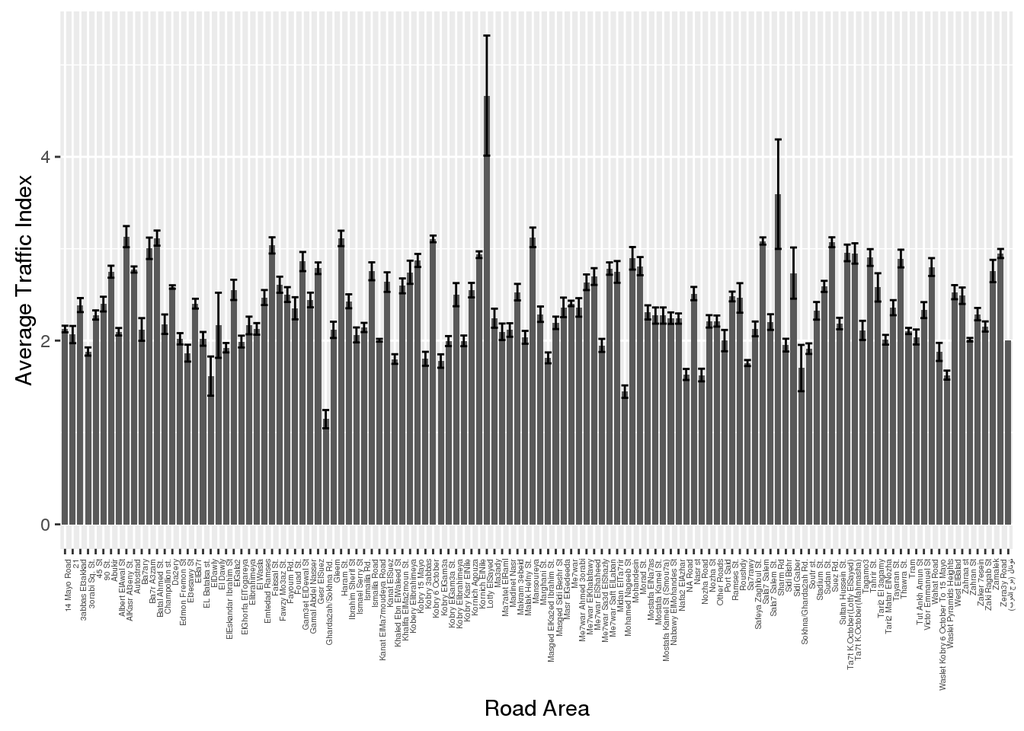

```r
avg_trf_ind_per_area <- data %>% filter(!is.na(rd.rp.stid) & rd.rp.stid < 6) %>% group_by(rd.area) %>% summarise(rd.rp.stid.avg = mean(rd.rp.stid), rd.rp.stid.avg.U = mean(rd.rp.stid) +  qnorm(0.975)*sd(rd.rp.stid)/sqrt(length(rd.rp.stid)), rd.rp.stid.avg.L = mean(rd.rp.stid) - qnorm(0.975)*sd(rd.rp.stid)/sqrt(length(rd.rp.stid)))


avg_trf_ind_per_area %>% ggplot(aes(x=rd.area, y=rd.rp.stid.avg)) + geom_bar(stat="identity", width = 0.8) + theme(axis.text.x = element_text(angle = 90, hjust = 1, size = 4)) + xlab("Road Area") + ylab("Average Traffic Index") + geom_errorbar(aes(ymax = rd.rp.stid.avg.U, ymin = rd.rp.stid.avg.L))
```

```r
avg_trf_ind_per_area[which.max(avg_trf_ind_per_area$rd.rp.stid.avg),]
```

```
## Source: local data frame [1 x 4]
##
##         rd.area rd.rp.stid.avg rd.rp.stid.avg.U rd.rp.stid.avg.L
##           (chr)          (dbl)            (dbl)            (dbl)
## 1 Lotfy ElSayed       4.666667         5.319988         4.013345
```

```r
avg_trf_ind_per_area[which.min(avg_trf_ind_per_area$rd.rp.stid.avg),]
```

```
## Source: local data frame [1 x 4]
##
##                rd.area rd.rp.stid.avg rd.rp.stid.avg.U rd.rp.stid.avg.L
##                  (chr)          (dbl)            (dbl)            (dbl)
## 1 Gharda2ah/Sokhna Rd.       1.145161         1.244388         1.045935
```

From the plot, it seems that the area with the least traffic index is “Gharda2ah/Sokhna Rd.” and the area with the most traffic index is “Lotfy ElSayed”.

We can see the same traffic index per day and hour to see the rush hour and the most crowded day.

```r
data$rd.date.wday <- (data$rd.rp.date %>% strptime("%Y-%m-%d %H:%M:%S") %>% as.POSIXlt(origin="1970-01-01", tz = "UTC"))$wday
data$rd.date.hour <- (data$rd.rp.date %>% strptime("%Y-%m-%d %H:%M:%S") %>% as.POSIXlt(origin="1970-01-01", tz = "UTC"))$hour
```

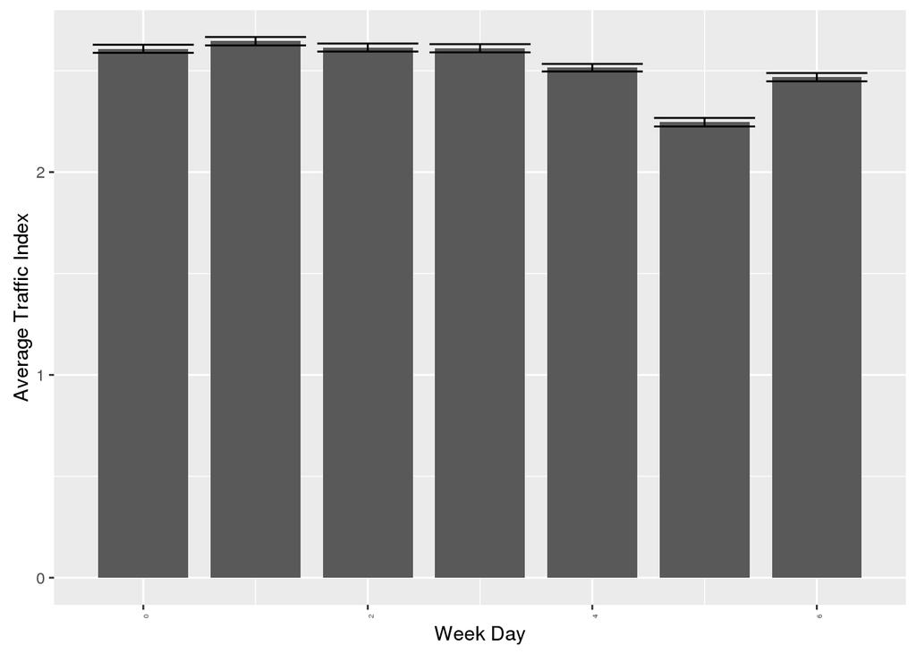

```r
avg_trf_ind_per_wday <- data %>% filter(!is.na(rd.rp.stid) & rd.rp.stid < 6) %>% group_by(rd.date.wday) %>% summarise(rd.rp.stid.avg.wday = mean(rd.rp.stid), rd.rp.stid.avg.wday.U = mean(rd.rp.stid) +  qnorm(0.975)*sd(rd.rp.stid)/sqrt(length(rd.rp.stid)), rd.rp.stid.avg.wday.L = mean(rd.rp.stid) - qnorm(0.975)*sd(rd.rp.stid)/sqrt(length(rd.rp.stid)))
avg_trf_ind_per_wday %>% ggplot(aes(x=rd.date.wday, y=rd.rp.stid.avg.wday)) + geom_bar(stat="identity", width = 0.8) + theme(axis.text.x = element_text(angle = 90, hjust = 1, size = 4)) + xlab("Week Day") + ylab("Average Traffic Index") + geom_errorbar(aes(ymax = rd.rp.stid.avg.wday.U, ymin = rd.rp.stid.avg.wday.L))
```

From this plot we can see that the day with the least traffic index is Friday while the one with the highest traffic index is Monday.

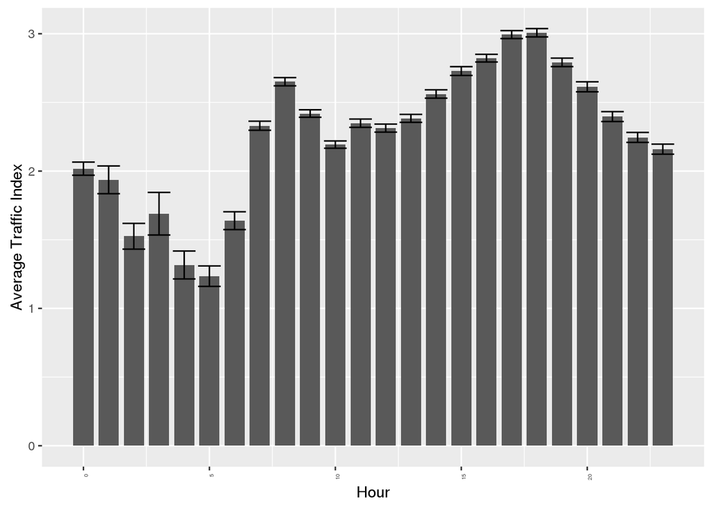

```r
avg_trf_ind_per_hour <- data %>% filter(!is.na(rd.rp.stid) & rd.rp.stid < 6) %>% group_by(rd.date.hour) %>% summarise(rd.rp.stid.avg.hour = mean(rd.rp.stid), rd.rp.stid.avg.hour.U = mean(rd.rp.stid) +  qnorm(0.975)*sd(rd.rp.stid)/sqrt(length(rd.rp.stid)), rd.rp.stid.avg.hour.L = mean(rd.rp.stid) - qnorm(0.975)*sd(rd.rp.stid)/sqrt(length(rd.rp.stid)))
avg_trf_ind_per_hour %>% ggplot(aes(x=rd.date.hour, y=rd.rp.stid.avg.hour)) + geom_bar(stat="identity", width = 0.8) + theme(axis.text.x = element_text(angle = 90, hjust = 1, size = 4)) + xlab("Hour") + ylab("Average Traffic Index") + geom_errorbar(aes(ymax = rd.rp.stid.avg.hour.U, ymin = rd.rp.stid.avg.hour.L))
```

And from this plot we can see that the maximum average traffic index occures at 6 PM while the least at 5 AM.